# cafe joris

Joris TULUMELLO

6 mars 2017

# Effet physiologique de la chemocyanine et de la LTP sur FRANKIA ACN14a

## Introduction

Bonjour à tous, comme vous le savez, Sam Sam nous a demandé de créer notre petit rapport R. C’est en quelque sorte la consécration ultime de ses petits cours et cela indique que (enfin) l’élève surpasse brillamment le maître (ou presque).

Aujourd’hui, nous allons nous amuser à analyser mes données de test physiologiques fraichement obtenues après 2 semaines de dur labeur !

Tout d’abord introduisons délicatement les données dans R.

Après avoir téléchargé celui-ci, placez le dans un petit dossier pour le rentrer dans R avec notre fameux petit package readxl!

```r
library(readxl)
dft <- read_excel(
    path = "../data-raw/test_physio_joris.xlsx",
    col_types = c(
        "text",
        "numeric",
        "numeric",
        "numeric",
        "numeric",
        "numeric",
        "numeric",
        "numeric",
        "numeric",
        "numeric",
        "numeric"
    )
)
```

Nous sommes obligés de rentrer le type de donnée pour chaque colonne car le package considère la colonne “respiration” comme des données “caractère”. Une autre manière de régler ce problème aurait été de changer le type de la colonne en question en utilisant la commande : `as.numeric(dft$respiration)`.

Vous constaterez qu’il s’agit d’un tableau contenant les différentes conditions de cultures de _Frankia__, les mesures d’éthylène, d’acétylène, du pic62 et de respiration. Nous ne nous encombreront plus de l’acétylène et du pic 62, ce ne sont que des indications que les mesures. Nous avons aussi les moyennes et l’écart-type pour l’éthylène et la respiration que j’ai calculé dans mon tableau Excel bien qu’une fonction R soit bien plus pratique.

Il ne nous reste plus qu’à analyser ces données :

Nettoyons les noms des colonnes avec “janitor” et regardons les nouveaux noms.

```r
dft <- janitor:: clean_names(dft)
names(dft)
```

```
##  [1] "condition"        "jour"             "numero"
##  [4] "mesure_ethylene"  "respiration"      "mesure_acetylene"
##  [7] "pic62"            "ec_eth"           "ec_resp"
## [10] "moy_eth"          "moy_resp"
```

## Représentation en point comme Sam Sam nous a appris !

On va d’abord s’intéresser à la fixation d’azote.

### Fixation d’azote

Si nous regardons le tableau, il n’est pas “tidy”. Nous voulons une seule colonne de mesure par condition. Il nous faut donc transformer le tableau avec la fonction `gather` de tidyverse. Nous créons ainsi la colonne `pic` qui correspond à `mesure_ethylene`,`respiration`,`moy_eth` et `moy_resp`.

```r
library(tidyverse)
dft <-
    gather(
        data = dft,
        key = pic,
        value = aire_de_pic,
        -condition,
        -jour,
        -numero,
        -mesure_acetylene,
        -pic62,
        -ec_eth,
        -ec_resp
    )
```

La colonne “aire_de_pic” créée ne concerne donc que les données de fixation et de respiration.

Faisons un petit graphique représentant l’aire de pic de l’éthylène en fonction des jours de mesure. Ceci est réalisable grâce à la fonction `filter` de tidyverse.

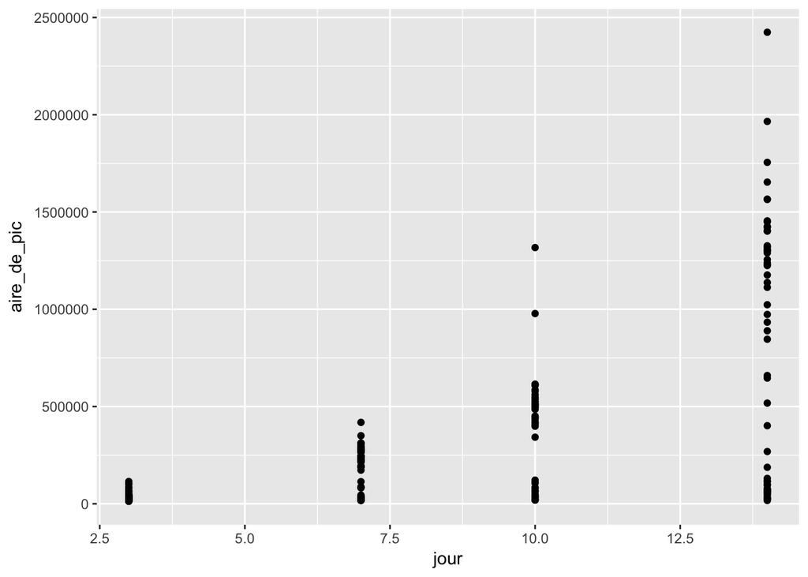

```r
dft %>%
  filter(pic == "mesure_ethylene") %>%
  ggplot(aes(x = jour, y = aire_de_pic)) +
  geom_point()
```

Tous les points sont regroupés et on ne voit rien. Mettons un peu de couleur en fonction des conditions!! Ceci grâce à l’esthétique `color` dans le geom et en précisant que la colonne condition est un facteur.

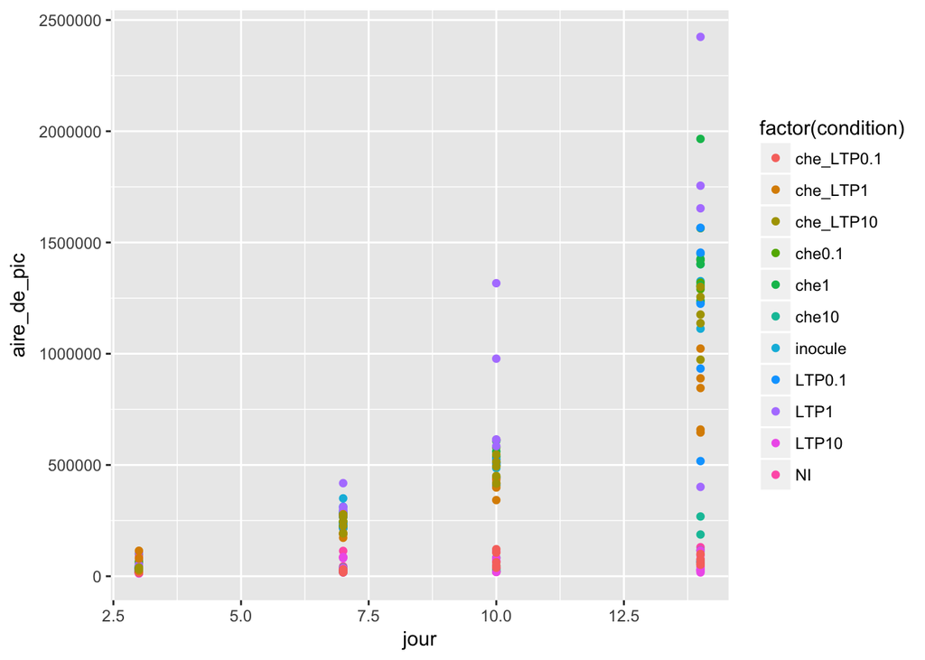

```r
dft %>%
  filter(pic == "mesure_ethylene") %>%
  ggplot(aes(x = jour, y = aire_de_pic)) +
  geom_point(aes(color = factor(condition)))
```

On retrouve toutes les conditions dans la légende… On peut donc lancer un long cri de joie! Et continuer en décalant les points pour chaque condition pour plus de lisibilité ;) Bénissons la commande “position” :

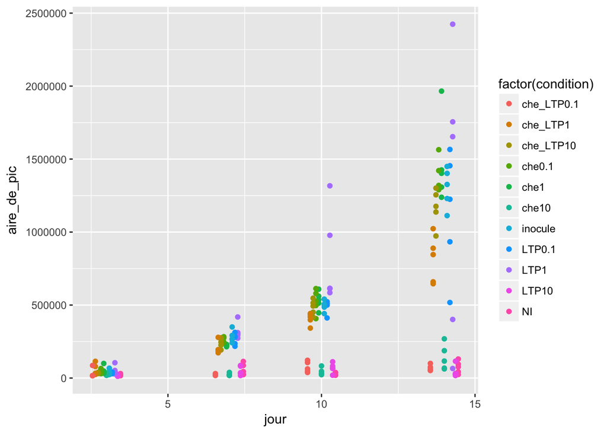

```r
dft %>%
  filter(pic == "mesure_ethylene") %>%
  ggplot(aes(x = jour, y = aire_de_pic)) +
  geom_point(aes(color = factor(condition)), position = position_dodge(width = 1))
```

Maintenant que les points sont bien séparés, le graphique est bien plus lisible !

Nous pouvons nous laisser tenter par une représentation des données avec une courbe pour nous aider à lire le graphique. Une courbe, ou une ligne rime avec… `geom_line` ! Et il suffit de copier-coller ce qu’il y a dans le geom_point dans le geom_line pour obtenir les mêmes transformations.

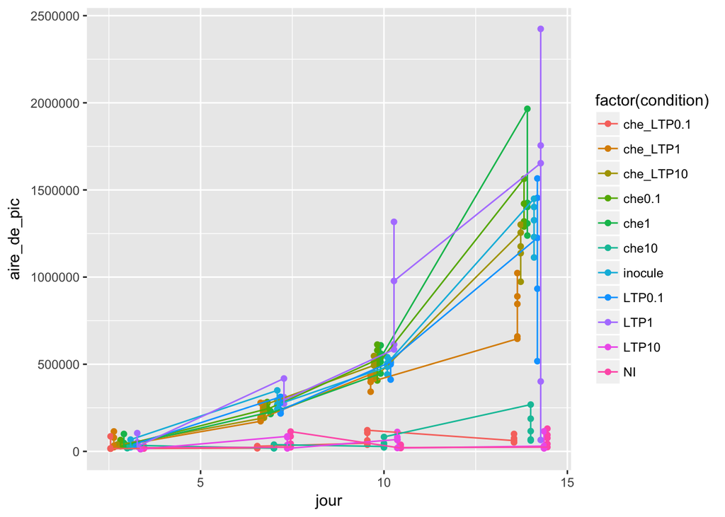

```r
dft %>%
  filter(pic == "mesure_ethylene") %>%
  ggplot(aes(x = jour, y = aire_de_pic)) +
  geom_point(aes(color = factor(condition)),
             position = position_dodge(width = 1)) +
  geom_line(aes(color = factor(condition)),
            position = position_dodge(width = 1))
```

Et oui ce n’est pas très beau… Après avoir pleuré un petit peu, on se rappelle des anciens cafés et on indique au geom line les notions de méthodes statistiques d’une jolie courbe bien courbe, à savoir stat = “smooth” et method = “loess”.

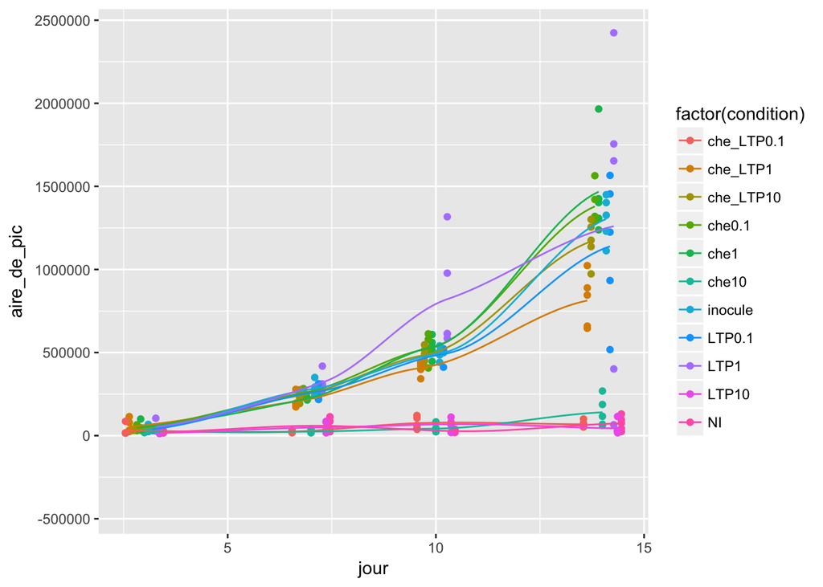

```r
dft %>%
  filter(pic == "mesure_ethylene") %>%
  ggplot(aes(x = jour, y = aire_de_pic)) +
  geom_point(aes(color = factor(condition)), position = position_dodge(width = 1)) +
  geom_line(aes(color = factor(condition)),
            stat = "smooth",
            method = "loess",
            position = position_dodge(width = 1))
```

Il nous reste plus qu’à transformer le graphique pour qu’il soit à peu près présentable pour affronter les permanents. Nous nous rappelons tous comment jouer avec la fonction “labs”, bien évidemment.

Il nous faut un beau titre, une légende et des axes bien écrits.

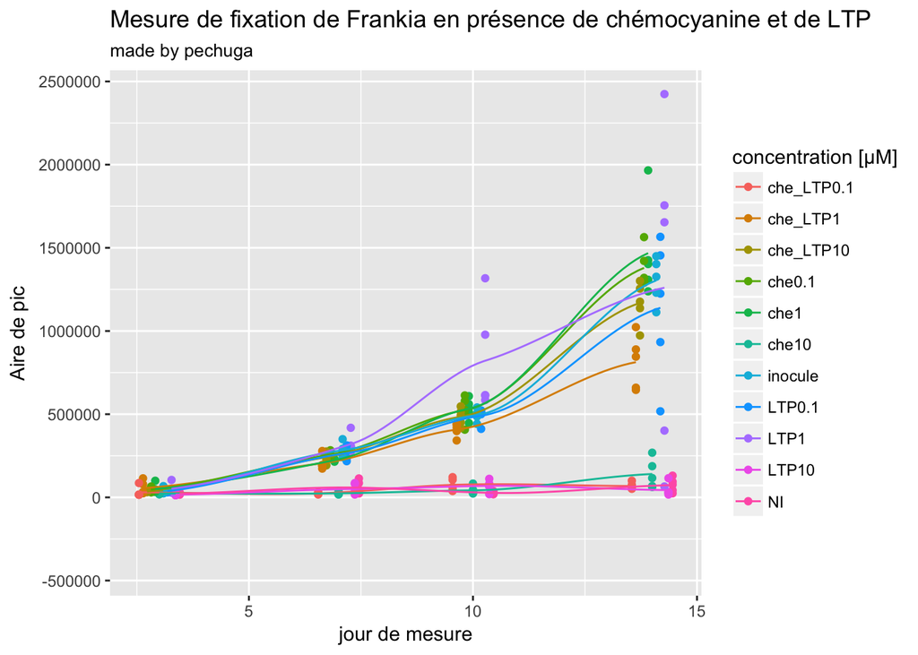

```r
dft %>%
  filter(pic == "mesure_ethylene") %>%
  ggplot(aes(x = jour, y = aire_de_pic)) +
  geom_point(aes(color = factor(condition)), position = position_dodge(width = 1)) +
  geom_line(aes(color = factor(condition)),
            stat = "smooth",
            method = "loess",
            position = position_dodge(width = 1)) +
  labs(x = "jour de mesure", y = "Aire de pic",color = "concentration [µM]",
       title = "Mesure de fixation de Frankia en présence de chémocyanine et de LTP",
       subtitle = "made by pechuga")
```

Il ne nous manque plus que de transformer les axes et changer le titre de place. `scale_x_continuous`,`scale_y_continuous` et `theme` sont là pour nous faciliter la vie. Ne pas oublier d’importer le package “scales”.

Nous voulons que l’axe des X représente les bons jours de mesure, soit 3, 7, 10 et 14. L’axe des y serait bien plus lisible si les chiffres étaient en notation scientifique. Un titre au milieu est ce que j’ai choisi et vous ne ferez pas autrement!

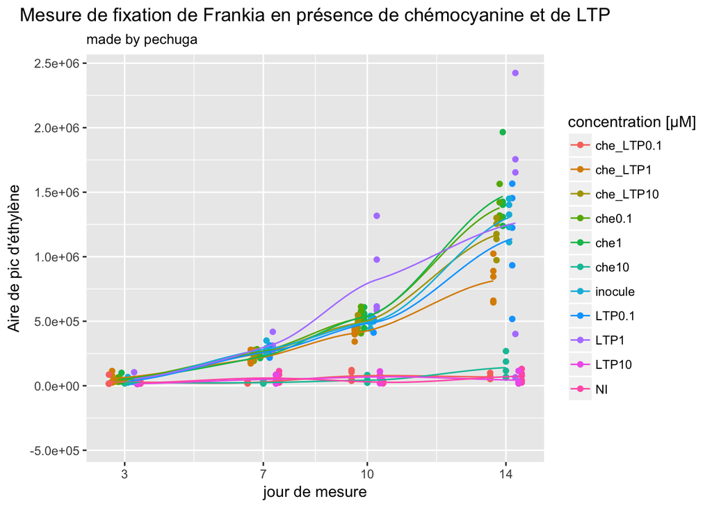

```r
library(scales)

dft %>%
    filter(pic == "mesure_ethylene") %>%
    ggplot(aes(x = jour, y = aire_de_pic)) +
    geom_point(aes(color = factor(condition)), position = position_dodge(width = 1)) +
    geom_line(
        aes(color = factor(condition)),
        stat = "smooth",
        method = "loess",
        position = position_dodge(width = 1)
    ) +
    labs(
        x = "jour de mesure",
        y = "Aire de pic d'éthylène",
        color = "concentration [µM]",
        title = "Mesure de fixation de Frankia en présence de chémocyanine et de LTP",
        subtitle = "made by pechuga"
    ) +
    scale_x_continuous(breaks = c(3, 7, 10, 14)) +
    scale_y_continuous(label = scientific) +
    theme(plot.title = element_text(hjust = 0.5))
```

On peut aller encore plus loin! En ajoutant la moyenne à chaque condition par jour! Ceci avec la fonction `Stat_summary`. On demande donc une moyenne des donnée en y avec `fun.y = mean`, en n’oubliant pas de garder le même code couleur et les mêmes positions ;) Finir par la forme de représentation avec `geom = "point", shape = "_"` et la taille qu’on veut.

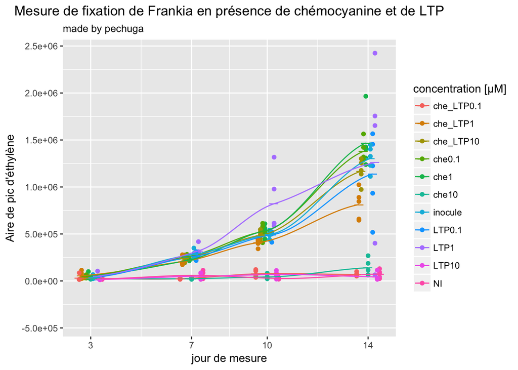

```r
dft %>%
    filter(pic == "mesure_ethylene") %>%
    ggplot(aes(x = jour, y = aire_de_pic)) +
    geom_point(aes(color = factor(condition)), position = position_dodge(width = 1)) +
    geom_line(
        aes(color = factor(condition)),
        stat = "smooth",
        method = "loess",
        position = position_dodge(width = 1)
    ) +
    labs(
        x = "jour de mesure",
        y = "Aire de pic d'éthylène",
        color = "concentration [µM]",
        title = "Mesure de fixation de Frankia en présence de chémocyanine et de LTP",
        subtitle = "made by pechuga"
    )  +
    stat_summary(
        fun.y = mean,
        aes(color = factor(condition)),
        geom = "point",
        shape = "_",
        size = 5,
        position = position_dodge(width = 1)
    ) +
    scale_x_continuous(breaks = c(3, 7, 10, 14)) +
    scale_y_continuous(label = scientific) +
    theme(plot.title = element_text(hjust = 0.5))
```

Pour finir, ma petite touche perso est d’avoir un thème blanc, alors j’utilise `theme_light()`. Puis j’ajoute des traits là ou ça m’arrange avec `geom_hline` et `geom_vline` pour des lignes horizontales ou verticales. On ajoute `yintercept =` ou `xintercept =` respectivement. Pour finir on peut modifier la couleur et la transparence à sa guise.

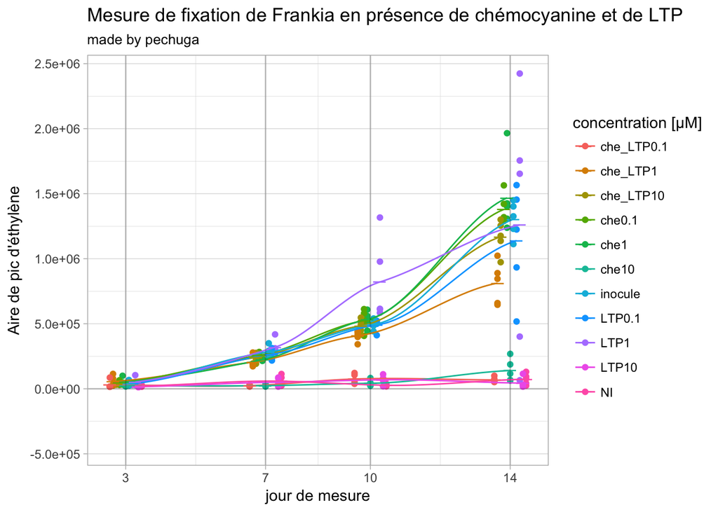

```r
dft %>%
    filter(pic == "mesure_ethylene") %>%
    ggplot(aes(x = jour, y = aire_de_pic)) +
    geom_point(aes(color = factor(condition)), position = position_dodge(width = 1)) +
    geom_line(
        aes(color = factor(condition)),
        stat = "smooth",
        method = "loess",
        position = position_dodge(width = 1)
    ) +
    labs(
        x = "jour de mesure",
        y = "Aire de pic d'éthylène",
        color = "concentration [µM]",
        title = "Mesure de fixation de Frankia en présence de chémocyanine et de LTP",
        subtitle = "made by pechuga"
    )  +
    stat_summary(
        fun.y = mean,
        aes(color = factor(condition)),
        geom = "point",
        shape = "_",
        size = 5,
        position = position_dodge(width = 1)
    ) +
    geom_hline(yintercept = 0,
               color = "black",
               alpha = 0.2) +
    geom_vline(xintercept = c(3, 7, 10, 14),
               color = "black",
               alpha = 0.2) +
    scale_x_continuous(breaks = c(3, 7, 10, 14)) +
    scale_y_continuous(label = scientific) +
    theme(plot.title = element_text(hjust = 0.5)) +
    theme_light()
```

### Représentation en histogramme

Mais parfois les chefs de sont pas toujours prêts à voir autant de point et demandent de représenter la moyenne et l’écart-type en histogramme… C’est pourquoi j’ai calculé le tout dans mon tableau. Ce qui est bien c’est que l’on peut quasiment tout copier-coller et remplacer le geom par geom_bar et hop le tour est quasiment joué ! Il faut ajouter que :

- Il faut sélectionner le pic “moy_eth”.
- La position devient simplement “dodge” dans le geom_bar.
- Il faut choisir la statistique “identity” dans le geom_bar.
- Pour les bars et histogramme, il faut remplir les bars avec “fill” et ne pas l’oublier dans la légende.

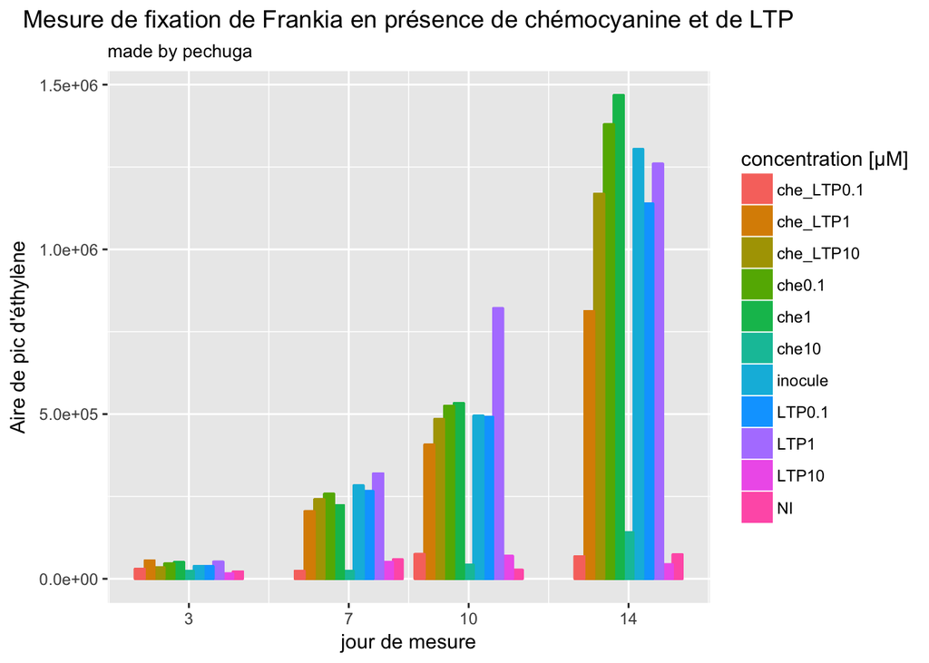

```r
dft %>%
    filter(pic == "moy_eth") %>%
    ggplot(aes(x = jour, y = aire_de_pic)) +
    geom_bar(aes(color = factor(condition), fill = factor(condition)),
             position = "dodge",
             stat = "identity") +
    labs(
        x = "jour de mesure",
        y = "Aire de pic d'éthylène",
        color = "concentration [µM]",
        fill = "concentration [µM]",
        title = "Mesure de fixation de Frankia en présence de chémocyanine et de LTP",
        subtitle = "made by pechuga"
    ) +
    scale_x_continuous(breaks = c(3, 7, 10, 14)) +
    scale_y_continuous(label = scientific) +
    theme(plot.title = element_text(hjust = 0.5))
```

Pour ajouter l’écart-type, on utilise `geom_errorbar` en indiquant le minimum par “ymin = moyenne du pic - écart-type du pic” et le maximum par “y max = moyenne du pic + écart-type du pic”. Le tout avec les mêmes couleurs et la même position dodge. C’est à dire 2,7 parce que j’ai tout essayé ! >_<

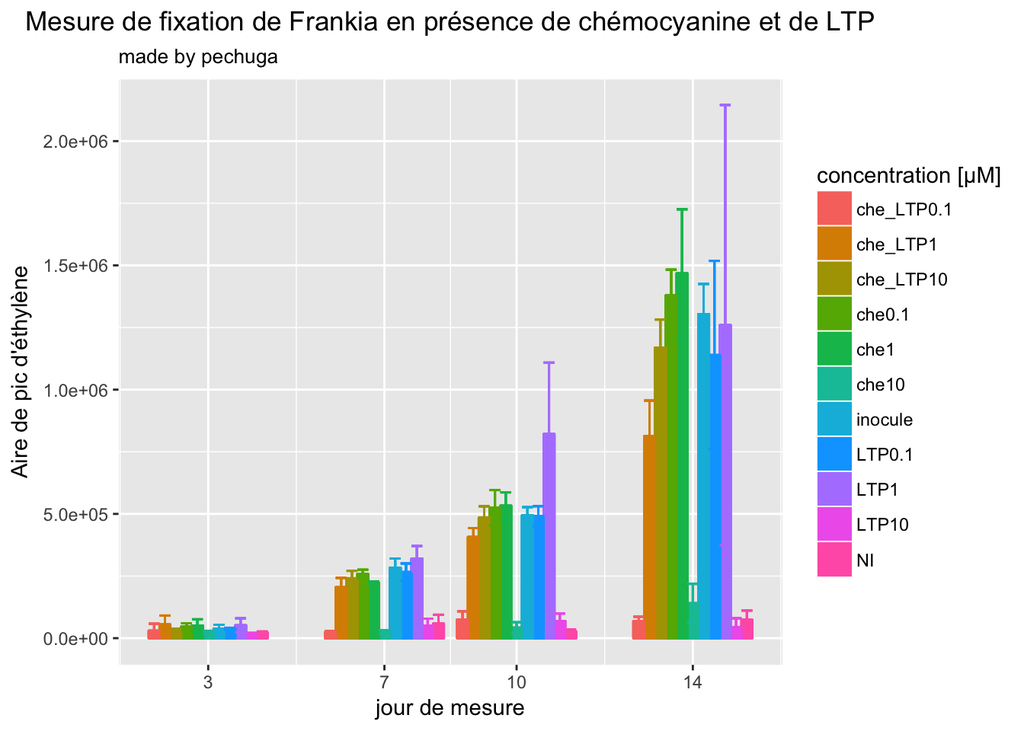

```r
dft %>%
    filter(pic == "moy_eth") %>%
    ggplot(aes(x = jour, y = aire_de_pic)) +
    geom_bar(aes(color = factor(condition), fill = factor(condition)),
             position = "dodge",
             stat = "identity") +
    geom_errorbar(
        aes(
            ymin = aire_de_pic - ec_eth,
            ymax = aire_de_pic + ec_eth,
            color = factor(condition)
        ),
        position = position_dodge(width = 2.7)
    ) +
    labs(
        x = "jour de mesure",
        y = "Aire de pic d'éthylène",
        color = "concentration [µM]",
        fill = "concentration [µM]",
        title = "Mesure de fixation de Frankia en présence de chémocyanine et de LTP",
        subtitle = "made by pechuga"
    ) +
    scale_x_continuous(breaks = c(3, 7, 10, 14)) +
    scale_y_continuous(label = scientific) +
    theme(plot.title = element_text(hjust = 0.5))
```

Et là on voit qu’on ne voit pas grand-chose… Mais il nous suffit de rendre le “fill” un peu transparent grâce à “alpha”! :D

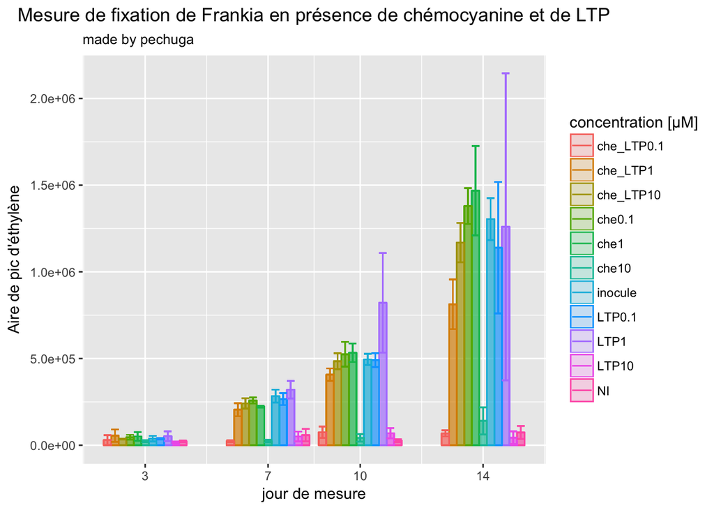

```r
dft %>%
    filter(pic == "moy_eth") %>%
    ggplot(aes(x = jour, y = aire_de_pic)) +
    geom_bar(
        aes(color = factor(condition), fill = factor(condition)),
        alpha = 0.2,
        position = "dodge",
        stat = "identity"
    ) +
    geom_errorbar(
        aes(
            ymin = aire_de_pic - ec_eth,
            ymax = aire_de_pic + ec_eth,
            color = factor(condition)
        ),
        position = position_dodge(width = 2.7)
    ) +
    labs(
        x = "jour de mesure",
        y = "Aire de pic d'éthylène",
        color = "concentration [µM]",
        fill = "concentration [µM]",
        title = "Mesure de fixation de Frankia en présence de chémocyanine et de LTP",
        subtitle = "made by pechuga"
    ) +
    scale_x_continuous(breaks = c(3, 7, 10, 14)) +
    scale_y_continuous(label = scientific) +
    theme(plot.title = element_text(hjust = 0.5))
```

Maintenant ce qui me déplait, c’est que les conditions sont ordonnées de manière alphabétique et non dont la manière dont je l’avais défini dans mon tableau. Mais dans la fonction “factor” je peux définir les différents niveaux et changer les noms avec “levels” et “labels”. Il suffit de rentrer après ces termes `c("NI", "inocule", "che0.1", "che.1", "che10", "LTP0.1", "LTP1", "LTP10", "che_LTP0.1", "che_LTP1", "che_LTP10")`. C’est très long et il faut l’écrire chaque fois que l’on rencontre “factor(condition)”. On va donc créer un vecteur contenant ces valeurs de niveaux et l’appeler chaque fois que l’on voudra l’utiliser. Appelons le “ord”.

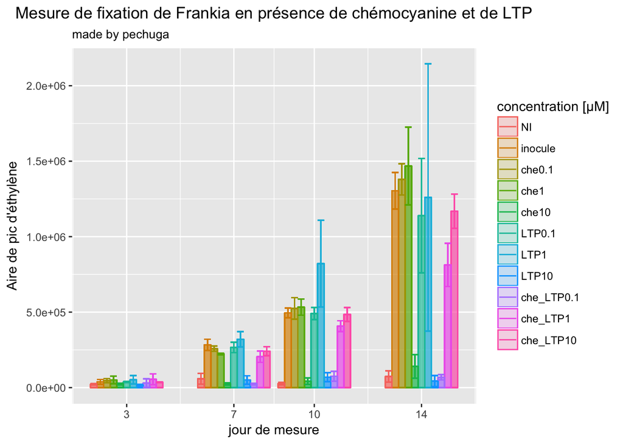

```r
ord <-
    c(
        "NI",
        "inocule",
        "che0.1",
        "che1",
        "che10",
        "LTP0.1",
        "LTP1",
        "LTP10",
        "che_LTP0.1",
        "che_LTP1",
        "che_LTP10"
    )


dft %>%
    filter(pic == "moy_eth") %>%
    ggplot(aes(x = jour, y = aire_de_pic)) +
    geom_bar(
        aes(
            color = factor(condition, levels = ord),
            fill = factor(condition, levels = ord)
        ),
        alpha = 0.2,
        position = "dodge",
        stat = "identity"
    ) +
    geom_errorbar(
        aes(
            ymin = aire_de_pic - ec_eth,
            ymax = aire_de_pic + ec_eth,
            color = factor(condition, levels = ord)
        ),
        position = position_dodge(width = 2.7)
    ) +
    labs(
        x = "jour de mesure",
        y = "Aire de pic d'éthylène",
        color = "concentration [µM]",
        fill = "concentration [µM]",
        title = "Mesure de fixation de Frankia en présence de chémocyanine et de LTP",
        subtitle = "made by pechuga"
    ) +
    scale_x_continuous(breaks = c(3, 7, 10, 14)) +
    scale_y_continuous(label = scientific) +
    theme(plot.title = element_text(hjust = 0.5))
```

Les données sont rangées de manière beaucoup plus logique et on peut donc s’attaquer à l’esthétisme pure et dur du graphique selons mes critères !

Commençons par la taille et l’épaisseur des barres d’erreurs, séparer les données par jour avec “facet_grid”, et changer le fond dans “theme”.

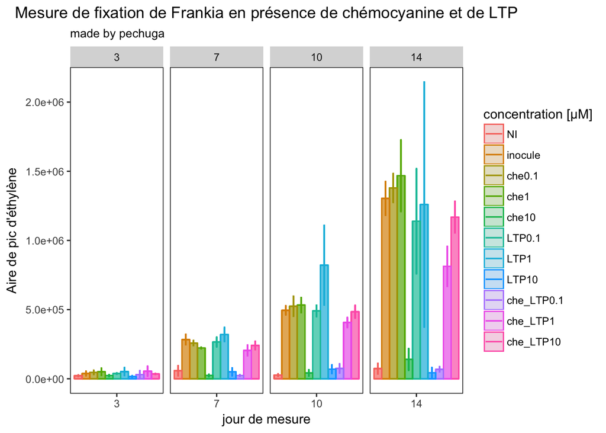

```r
dft %>%
    filter(pic == "moy_eth") %>%
    ggplot(aes(x = jour, y = aire_de_pic)) +
    geom_bar(
        aes(
            color = factor(condition, levels = ord),
            fill = factor(condition, levels = ord)
        ),
        alpha = 0.2,
        position = "dodge",
        stat = "identity"
    ) +
    geom_errorbar(
        aes(
            ymin = aire_de_pic - ec_eth,
            ymax = aire_de_pic + ec_eth,
            color = factor(condition, levels = ord)
        ),
        width = .5,
        size = 0.6,
        position = position_dodge(width = 2.7)
    ) +
    labs(
        x = "jour de mesure",
        y = "Aire de pic d'éthylène",
        color = "concentration [µM]",
        fill = "concentration [µM]",
        title = "Mesure de fixation de Frankia en présence de chémocyanine et de LTP",
        subtitle = "made by pechuga"
    ) +
    scale_x_continuous(breaks = c(3, 7, 10, 14)) +
    scale_y_continuous(label = scientific) +
    facet_grid( ~ jour, scales = "free") +
    theme(
        plot.title = element_text(hjust = 0.5),
        panel.background = element_rect(fill = "white"),
        panel.border = element_rect(fill = NA)
    )
```

Et voilà !! On s’est beaucoup amusé ! :D

Mais ce n’est pas fini ! Il nous manque encore à traiter la respiration !

### Respiration

Ce qui est beau c’est que l’on a juste à copier-coller le script du graphique en point et de l’histogramme et de remplacer les données par celles de la respiration. Attention à changer les légendes !

Le plus facile est celui des points :

- On prend les données de respiration.
- On change le titre pour la respiration.
- On change l’axe des y par la DO490.

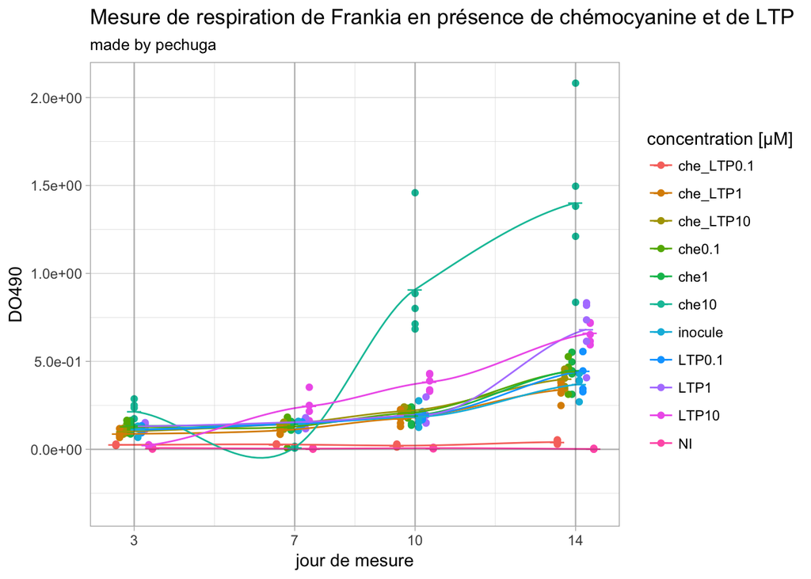

```r
dft %>%
    filter(pic == "respiration") %>%
    ggplot(aes(x = jour, y = aire_de_pic)) +
    geom_point(aes(color = factor(condition)), position = position_dodge(width = 1)) +
    geom_line(
        aes(color = factor(condition)),
        stat = "smooth",
        method = "loess",
        position = position_dodge(width = 1)
    ) +
    labs(
        x = "jour de mesure",
        y = "DO490",
        color = "concentration [µM]",
        title = "Mesure de respiration de Frankia en présence de chémocyanine et de LTP",
        subtitle = "made by pechuga"
    )  +
    stat_summary(
        fun.y = mean,
        aes(color = factor(condition)),
        geom = "point",
        shape = "_",
        size = 5,
        position = position_dodge(width = 1)
    ) +
    geom_hline(yintercept = 0,
               color = "black",
               alpha = 0.2) +
    geom_vline(xintercept = c(3, 7, 10, 14),
               color = "black",
               alpha = 0.2) +
    scale_x_continuous(breaks = c(3, 7, 10, 14)) +
    scale_y_continuous(label = scientific) +
    theme(plot.title = element_text(hjust = 0.5)) +
    theme_light()
```

Pour l’histogramme il y a plus de choses à modifier mais cela reste assez abordable :

- On prend les données “moy_resp”.
- On change les calcule d’erreur standard avec les bons écart-types.
- On modifie le titre et la légende.

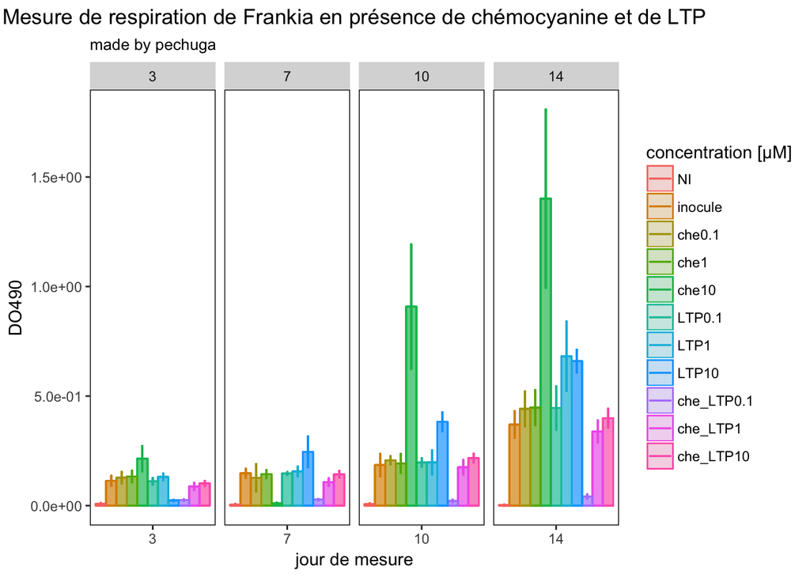

```r
dft %>%
    filter(pic == "moy_resp") %>%
    ggplot(aes(x = jour, y = aire_de_pic)) +
    geom_bar(
        aes(
            color = factor(condition, levels = ord),
            fill = factor(condition, levels = ord)
        ),
        alpha = 0.2,
        position = "dodge",
        stat = "identity"
    ) +
    geom_errorbar(
        aes(
            ymin = aire_de_pic - ec_resp,
            ymax = aire_de_pic + ec_resp,
            color = factor(condition, levels = ord)
        ),
        width = .5,
        size = 0.6,
        position = position_dodge(width = 2.7)
    ) +
    labs(
        x = "jour de mesure",
        y = "DO490",
        color = "concentration [µM]",
        fill = "concentration [µM]",
        title = "Mesure de respiration de Frankia en présence de chémocyanine et de LTP",
        subtitle = "made by pechuga"
    ) +
    scale_x_continuous(breaks = c(3, 7, 10, 14)) +
    scale_y_continuous(label = scientific) +
    facet_grid( ~ jour, scales = "free") +
    theme(
        plot.title = element_text(hjust = 0.5),
        panel.background = element_rect(fill = "white"),
        panel.border = element_rect(fill = NA)
    )
```

Et voilà nous sommes fin prêt pour nous amuser à inférer à tort et à travers avant de se faire frapper sur les doigts pour recommencer toute les manips!!